## 載入插件

```python
pip install openpyxl
```

```python
import matplotlib.pyplot as plt
import pandas as pd
from matplotlib import font_manager as fm
from matplotlib import cm
import matplotlib
import openpyxl
import numpy as np
from openpyxl.utils import get_column_letter, column_index_from_string
plt.rcParams["figure.dpi"] = 200
def autolabel(rects):
    """Attach a text label above each bar in *rects*, displaying its height."""
    for rect in rects:
        height = rect.get_height()
        ax.annotate('{}'.format(height),
                    xy=(rect.get_x() + rect.get_width() / 2, height),
                    xytext=(0, 3),  # 3 points vertical offset
                    textcoords="offset points",
                    ha='center', va='bottom')
```

## 載入資料集

```python
datao = pd.read_excel(r"C:\Users\User\OneDrive\桌面\統計學下\output.xlsx")
dataw = pd.read_excel(r"C:\Users\User\OneDrive\桌面\統計學下\web.xlsx")
```

```python
wb = openpyxl.load_workbook(r"C:\Users\User\OneDrive\桌面\統計學下\web.xlsx")
sheet = wb.active
```

## 拋棄的語法

```python
# ds = t.iloc[1][0]

# print(ds)
# web= sheet['B2':'B9541']
# tr=sheet['O2':'O9541']

# for row_cells in web:
#     for cell in row_cells:
#         #print(cell.value)

#         rename=cell.value
```

```python
#pd.set_option('display.max_columns', None)
#pd.set_option('display.max_rows', None)

#l= datao[u'Location'].value_counts().to_frame()
#if l<19
#    print(l)
```

```python
#LH=datao.groupby(["Location","Hosted_by"]).size()
#print(LH)

#ans=LH.size().reset_index(name='counts')
#print(df)

#df = new_r
#print(df['Host'])

#us_sum = datao[datao['Location']=='United States'][datao['Location'].value_counts()].sum()
#fr_sum = df[df['Location''France']=='France']['Hosted_by'].sum()
#ne_sum = df[df['Location']=='Netherlands']['Hosted_by'].sum()
#ge_sum = df[df['Location']=='Germany']['Hosted_by'].sum()
```

## Q:哪個網站無論在哪個國家都有上前50名流量榜?

### Q:Which website is on the top 50 traffic list in any country?

```python
w=dataw[u'Website'].value_counts().rename_axis('website').to_frame('traffic counts')
ans=dataw[u'Website'].value_counts() >= 191
w[ans]
```

| website | traffic counts |
| --- | --- |
| www.wikipedia.org | 191 |
| www.google.com | 191 |

## Interpretation:

由此可見，google.com與wikipedia.org這兩個網站，是所有統計國家(191個國家)裡，都有上榜的。  
可以說這是真正實踐「世界普遍」的兩個網站。

## Q:哪些國家的流量網站較多?(將所有不到1%的項目合併並視為其他。)

### Q:Which countries have more traffic sites? (All categories below 1% are calculated into Others.)

```python
l=datao[u'Location'].value_counts().to_frame()
l_index = l.reset_index()
print(l_index.head(9))
print(l.head(9))
#print(l.sum())
```

```
                index  Location
0       United States      1641
1              France       141
2         Netherlands        82
3             Germany        81
4  Russian Federation        74
5      United Kingdom        66
6      Czech Republic        42
7             Ireland        41
8               China        30
                    Location
United States           1641
France                   141
Netherlands               82
Germany                   81
Russian Federation        74
United Kingdom            66
Czech Republic            42
Ireland                   41
China                     30
```

```python
print('3340/100=',3340/100,"，故所有小於",round(3340/100),"的項目將合併為其他。")
```

```
3340/100= 33.4 ，故所有小於 33 的項目將合併為其他。
```

```python
under33n=datao[u'Location'].value_counts() < 33
print(l[under33n])

num_of_other_n=l[under33n].Location.sum()
#print(num_of_other_n)
```

```
                           Location
China                            30
Vietnam                          29
Iran, Islamic Republic of        28
Singapore                        27
Uzbekistan                       26
...                             ...
Belize                            1
Yemen                             1
Gabon                             1
Andorra                           1
Cayman Islands                    1

[148 rows x 1 columns]
```

```python
over33n=datao[u'Location'].value_counts() >= 33
#print(over33n)

#type(l[over33n])
#type(l)dataframe
#type(over33n)series
#type(datao[u'Location'])series
#type(new_over33n)dataframe

new_over33n = l[over33n].append({"Location":num_of_other_n}, ignore_index=True)
print(new_over33n)
```

```
   Location
0      1641
1       141
2        82
3        81
4        74
5        66
6        42
7        41
8      1172
```

```
{'United States': 1641,
 'France': 141,
 'Netherlands': 82,
 'Germany': 81,
 'Russian Federation': 74,
 'United Kingdom': 66,
 'Czech Republic': 42,
 'Ireland': 41,
 'Others': 1172}
```

```
[41, 42, 66, 74, 81, 82, 141, 1172, 1641]
```

```
['Ireland',
 'Czech Republic',
 'United Kingdom',
 'Russian Federation',
 'Germany',
 'Netherlands',
 'France',
 'Others',
 'United States']
```

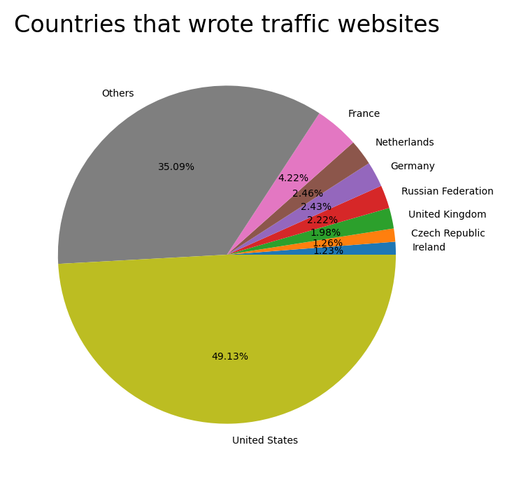

```python
mydict = dict(zip(l_index['index'][:8],l_index['Location'][:8]))
mydict['Others'] = new_over33n.loc[8,'Location']
display(mydict)
sorted_dict = sorted(mydict.values())
print(sorted_dict)
sorted_labels = []

for val in sorted_dict:
    for item in mydict.items():
        if(val == item[1]):
            sorted_labels.append(item[0])
display(sorted_labels)
plt.pie(sorted_dict,  autopct='%1.2f%%',labels = sorted_labels,textprops={'fontsize': 5})
plt.title('Countries that wrote traffic websites')
# plt.legend()
plt.show()
```

## Q:哪些公司製作的流量網站占比最高?(將所有不到1%的項目合併並視為其他。)

### Q:Which companies have made higher percentage of traffic websites?(All categories below 1% are calculated into Others.)

```python
h=datao[u'Hosted_by'].value_counts().to_frame()
h_index = h.reset_index()
print(h)
ans=h['Hosted_by'].sum()
print('所有流量網站的數量為',ans)
```

```
                                                    Hosted_by
CloudFlare, Inc.                                          593
Google Inc.                                               236
Akamai Technologies, Inc.                                 158
Amazon Technologies Inc.                                   74
OVH SAS                                                    64
...                                                       ...
TL colocation customers                                     1
SINDO NEWS                                                  1
Legal Entity Under Public Law Financial Analyti...          1
FM Infrastructure and DMZ                                   1
WiFi Service                                                1

[1237 rows x 1 columns]
所有流量網站的數量為 3298
```

```python
print('3298/10=',3298/100,"，故所有小於",round(3298/100),"的項目將合併為其他。")
```

```
3298/10= 32.98 ，故所有小於 33 的項目將合併為其他。
```

```python
under33c=datao[u'Hosted_by'].value_counts() < 33
print(h[under33c])

num_of_other_c=h[under33c].Hosted_by.sum()
print(num_of_other_c)
```

```
                                                    Hosted_by
NTT America, Inc.                                          30
GoDaddy.com, LLC                                           29
Fastly                                                     26
Amazon Data Services Ireland Limited                       20
Digital Ocean, Inc.                                        18
...                                                       ...
TL colocation customers                                     1
SINDO NEWS                                                  1
Legal Entity Under Public Law Financial Analyti...          1
FM Infrastructure and DMZ                                   1
WiFi Service                                                1

[1228 rows x 1 columns]
2005
```

```python
over33c=datao[u'Hosted_by'].value_counts() >= 33
#print(over33c)
index = h_index[:9]
index.loc[len(index.index)] = ['Others', num_of_other_c]
print(index)

new_over33c = h[over33c].append({"Hosted_by":num_of_other_c}, ignore_index=True)
print(new_over33c)
```

```
                       index  Hosted_by
0           CloudFlare, Inc.        593
1                Google Inc.        236
2  Akamai Technologies, Inc.        158
3   Amazon Technologies Inc.         74
4                    OVH SAS         64
5           Amazon.com, Inc.         56
6        Hetzner Online GmbH         40
7              Incapsula Inc         38
8              Unified Layer         34
9                     Others       2005
   Hosted_by
0        593
1        236
2        158
3         74
4         64
5         56
6         40
7         38
8         34
9       2005
```

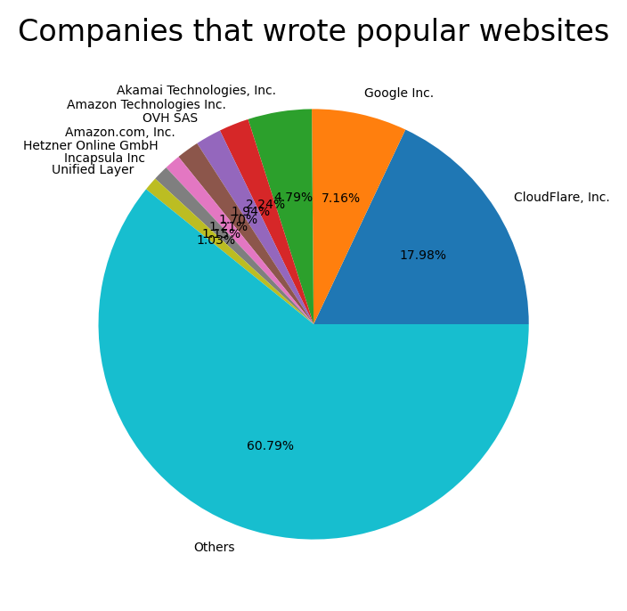

```python
plt.pie(new_over33c['Hosted_by'], labels= index['index'], autopct='%1.2f%%',textprops={'fontsize': 5},)
plt.title('Companies that wrote popular websites')

plt.show()
```

## Q:那麼產出這些超過1%的流量網的國家都擁有哪些公司呢?

### Q:So what companies are owned by the countries that produce more than 1% of the traffic website?

```python
L=datao['Location']
H=datao["Hosted_by"]

result={'Country':L, 'Host':H }
new_r = pd.DataFrame(result).value_counts().to_frame('counts')
Co=new_r.values.tolist()
# display(Co)
# print(Co)
# 將Co 從list of list 改成 list of int
Co_num = []
for i in range(len(Co)):
    Co_num.append(Co[i][0])
# print(Co_num)
Co.clear()
Co = Co_num
# ----------------------------------
Lo=datao['Location'].values.tolist()
Ho=datao["Hosted_by"].values.tolist()

merge=list(zip(Lo,Ho,Co))
# display(merge)
df = pd.DataFrame(merge,
    columns=['L', 'H', 'C'])
display(df)

# 刪掉count小於5的
df1 = df
df1.loc[df['C']<=5,'H'] = 'Others'
df1 = df1.groupby(['L', 'H']).sum()
df1.sort_values(by=['L'], inplace=True, ascending=False)
df1.reset_index(inplace = True)
display(df1)

# 刪掉不是八大國家的
big_country = ['United States','Ireland','France','Netherlands','Germany','Russian Federation','Czech Republic','United Kingdom']
df1 = df1[df1['L'].isin(big_country)]
display(df1)
```

|  | L | H | C |
| --- | --- | --- | --- |
| 0 | United States | Google Inc. | 593 |
| 1 | United States | Google Inc. | 236 |
| 2 | United States | Google Inc. | 153 |
| 3 | Ireland | Facebook | 61 |
| 4 | United States | Yahoo! Inc. | 58 |
| ... | ... | ... | ... |
| 1269 | United States | CDNetworks Inc. | 1 |
| 1270 | Georgia | LTD CGC Co | 1 |
| 1271 | Czech Republic | Livesport | 1 |
| 1272 | Georgia | Crystalbet Ltd | 1 |
| 1273 | Georgia | CLOUD9 GE | 1 |

1274 rows × 3 columns

|  | L | H | C |
| --- | --- | --- | --- |
| 0 | United States | Zapways | 9 |
| 1 | United States | Microsoft Corporation | 48 |
| 2 | United States | ARYAN ICT Solutions, LLC | 51 |
| 3 | United States | Akamai Technologies, Inc. | 52 |
| 4 | United States | Amazon Technologies Inc. | 14 |
| ... | ... | ... | ... |
| 104 | Armenia | Others | 4 |
| 105 | Argentina | Others | 21 |
| 106 | Andorra | Others | 3 |
| 107 | Algeria | Others | 7 |
| 108 | Albania | Others | 8 |

109 rows × 3 columns

|  | L | H | C |
| --- | --- | --- | --- |
| 0 | United States | Zapways | 9 |
| 1 | United States | Microsoft Corporation | 48 |
| 2 | United States | ARYAN ICT Solutions, LLC | 51 |
| 3 | United States | Akamai Technologies, Inc. | 52 |
| 4 | United States | Amazon Technologies Inc. | 14 |
| 5 | United States | Automattic, Inc | 7 |
| 6 | United States | CloudFlare, Inc. | 39 |
| 7 | United States | Facebook, Inc. | 9 |
| 8 | United States | Fastly | 38 |
| 9 | United States | Google Inc. | 990 |
| 10 | United States | Incapsula Inc | 6 |
| 11 | United States | LinkedIn Corporation | 9 |
| 12 | United States | Mindspark Interactive Network, Inc. | 10 |
| 13 | United States | NTT America, Inc. | 29 |
| 14 | United States | OVH Hosting, Inc. | 7 |
| 15 | United States | Others | 930 |
| 16 | United States | Rackspace Hosting | 6 |
| 17 | United States | SingleHop, Inc. | 34 |
| 18 | United States | Twitter Inc. | 8 |
| 19 | United States | Unified Layer | 6 |
| 20 | United States | Wikimedia Foundation Inc. | 34 |
| 21 | United States | Yahoo! Inc. | 58 |
| 22 | United Kingdom | UK-2 Limited | 9 |
| 23 | United Kingdom | Others | 29 |
| 24 | United Kingdom | Everbread Limited IP Space | 8 |
| 34 | Russian Federation | Others | 29 |
| 35 | Russian Federation | "HLL" LLC | 6 |
| 39 | Netherlands | Others | 61 |
| 40 | Netherlands | Webzilla B.V. | 9 |
| 49 | Ireland | Others | 15 |
| 50 | Ireland | Facebook | 61 |
| 56 | Germany | Others | 49 |
| 60 | France | Others | 77 |
| 71 | Czech Republic | Others | 32 |

```
34
```

[figure not shown]

```python
plt.rcParams["figure.dpi"] = 300

us_sum = df1[df1['L']=='United States']['C'].sum()
fr_sum = df1[df1['L']=='France']['C'].sum()
ne_sum = df1[df1['L']=='Netherlands']['C'].sum()
ge_sum = df1[df1['L']=='Germany']['C'].sum()
ru_sum = df1[df1['L']=='Russian Federation']['C'].sum()
uk_sum = df1[df1['L']=='United Kingdom']['C'].sum()
cr_sum = df1[df1['L']=='Czech Republic']['C'].sum()
ir_sum = df1[df1['L']=='Ireland']['C'].sum()

fig, ax = plt.subplots()
# distance = 0.6
# explode = (0, 0, 0, 0, 0, 0, 0, distance, distance, distance, distance, distance, distance, distance, distance, distance, distance, distance, distance, distance, distance, distance, distance, distance, distance, distance, distance, distance,)
# inside = 0.2
# seperate = (0,inside, inside,inside, inside,inside, inside,inside,)
size = 0.4



colors_out = ['#003060','#003D79','#004B97','#005AB5','#0066CC','#0072E3','#0080FF','#2894FF','#46A3FF','#66B3FF','#84C1FF','#66B3FF','#46A3FF','#2894FF','#0080FF','#0072E3','#0066CC','#005AB5','#004B97','#0066CC','#005AB5','#004B97','#612457','#6a1b52','#793465','#bf2b60','#F50000','#FF5959','#bc421a','#E09200','#e7b040','#F0F000','#47bb3e','#426c33']
colors_ins = ['#2a52be','purple','#c10066','red','orange','yellow','#99DD00','green']

print(len(df1['C']))
ax.pie(df1['C'], labels=df1['H'],
       autopct='%1.2f%%', pctdistance=0.8,  textprops={'fontsize': 3}, colors = colors_out,
       radius=1, wedgeprops=dict(width=size, edgecolor='w'))

ax.pie([us_sum,  uk_sum,ru_sum,ne_sum,ir_sum, ge_sum, fr_sum,cr_sum], labels=['United States', 'France','Netherlands','Germany','Russian Federation', 'United Kingdom','Czech Republic','Ireland' ], labeldistance=0.2,
       autopct='%1.2f%%', pctdistance=0.6,textprops={'fontsize': 2}, colors= colors_ins,
       radius=1-size, wedgeprops=dict(width=size, edgecolor='w'))

plt.title('Countries, companys that wrote traffic websites')
plt.show()
```

[figure not shown]

```python
plt.rcParams["figure.dpi"] = 200
fig, ax = plt.subplots()
ax.pie([us_sum, fr_sum, ir_sum, ne_sum, ge_sum, uk_sum, ru_sum, cr_sum], labels=['United States', 'France', 'Ireland', 'Netherlands', 'Germany', 'United Kingdom', 'Russian Federation', 'Czech Republic'], labeldistance=0.8,
       autopct='%1.2f%%', pctdistance=0.6,
       radius=1, wedgeprops=dict(width=size, edgecolor='white'))
plt.title('Population')
plt.show()
```

## 概念釐清用

```python
l= datao[u'Location'].value_counts().to_frame()
print(l)

c=datao[u'country'].value_counts().to_frame()
print(c)

t=datao[u'Traffic_Rank'].value_counts().to_frame()
print(t)

h=datao[u'Hosted_by'].value_counts().to_frame()
print(h)
```

```
                    Location
United States           1641
France                   141
Netherlands               82
Germany                   81
Russian Federation        74
...                      ...
Belize                     1
Yemen                      1
Gabon                      1
Andorra                    1
Cayman Islands             1

[156 rows x 1 columns]
                                  country
Afghanistan                            50
China                                  45
Albania                                43
Macedonia                              42
Iran                                   39
...                                   ...
United Kingdom                          5
Togo                                    5
Saint Vincent and The Grenadines        5
Gabon                                   4
Guadeloupe                              4

[191 rows x 1 columns]
        Traffic_Rank
1 116              4
252                4
1 043              4
990                3
468                3
...              ...
17 499             1
6 613              1
5 474              1
36 331             1
30 947             1

[3195 rows x 1 columns]
                                                    Hosted_by
CloudFlare, Inc.                                          593
Google Inc.                                               236
Akamai Technologies, Inc.                                 158
Amazon Technologies Inc.                                   74
OVH SAS                                                    64
...                                                       ...
TL colocation customers                                     1
SINDO NEWS                                                  1
Legal Entity Under Public Law Financial Analyti...          1
FM Infrastructure and DMZ                                   1
WiFi Service                                                1

[1237 rows x 1 columns]
```

```python
# df = pd.DataFrame([
#     ['France', 61083916, 'Europe'], ['Germany', 82400996, 'Europe'], ['Italy', 58147733, 'Europe'],
#     ['Spain', 40448191, 'Europe'], ['United Kingdom', 60776238, 'Europe'], ['Taiwan', 23174294, 'Asia'],
#     ['Japan', 127467972, 'Asia'], ['Korean', 49044790, 'Asia'], ['China', 1318683096, 'Asia']],
#     columns=['country', 'pop', 'continent'])


# europe_sum = df[df['continent']=='Europe']['pop'].sum()
# asia_sum = df[df['continent']=='Asia']['pop'].sum()
# fig, ax = plt.subplots()
# size = 0.4
# ax.pie(df['pop'], labels=df['country'],
#        autopct='%1.2f%%', pctdistance=0.8,
#        radius=1, wedgeprops=dict(width=size, edgecolor='w'))
# ax.pie([europe_sum, asia_sum], labels=['Europe', 'Asia'], labeldistance=0.2,
#        autopct='%1.2f%%', pctdistance=0.6,
#        radius=1-size, wedgeprops=dict(width=size, edgecolor='w'))
# plt.title('Population')
# plt.show()
```